# Combine two Zhang samples

Alexey Larionov

23 Feb 2021

# 1 Summary

- Read source data to GRanges
  - 655 genes with coordinates: alteady in GRanges (using Seqinfo(genome="hg38"))
  - two Zhang samples: convert to GRanges using the same Seqinfo as in the 655 genes
- Preprocess
  - Select variants on standard chromosomes
  - Select variants overlapping with 655 genes
  - Exclude common variants (MAF > 0.05)
- Split x and y to subsets
  - Make Chr_Start_End_Ref_Alt key
  - Make subsets: unique x, y and overlap of x and y
- Select variant annotations
  - Make vector of stable variant annotations to keep in GRanges
  - Make NA matrices for sample-specific variant annotations
- Process unique x and y
  - Make GRanges for unique x and y
  - Capture sample-specific annotations to the matrices
- Porcess overlapping x and y
  - Make GRange for intersect of x and y
  - Capture sample-specific annotations to the matrices
- Combine all variants
  - Merge unique and overlapping GRanges
  - Sort the merged GRanges
  - Sync matrices rows with the sorted GRanges
- Save to SummarisedExperiment

# 2 Start section

```r
# Time stamp
Sys.time()
```

```
## [1] "2021-02-23 13:01:03 GMT"
```

```r
# Clenan-up
rm(list=ls())
graphics.off()

# Memory
gc()
```

```
##          used (Mb) gc trigger (Mb) limit (Mb) max used (Mb)
## Ncells 415247 22.2     865661 46.3         NA   641517 34.3
## Vcells 789863  6.1    8388608 64.0      16384  1768547 13.5
```

```r
# Options
options(stringsAsFactors=F)

# Files and folders
base_folder <- "/Users/alexey/Documents/mg/s2021/zhang_tests"
data_folder <- file.path(base_folder,"data","s06_combine_samples")
scripts_fiolder <- file.path(base_folder,"scripts","s06_combine_samples")
setwd(scripts_fiolder)

# Libraries
library(GenomicRanges)
library(VennDiagram)
library(SummarizedExperiment)
```

# 3 Read data

## 3.1 655 (of 667) genes

```r
# Load data
load(file.path(base_folder,"scripts","s04_gene_list_with_coordinates","s03_667_gene_coordinates.RData"))

# Remove unnecessary objects
rm(working_folder,absent_genes_9.df,genes_628.gr,genes_658.grl,genes_667.df,
   multi_genes_3.df, multi_genes_3.grl,multi_genes_30.df,multi_genes_30.grl)

# Update folders
base_folder <- "/Users/alexey/Documents/mg/s2021/zhang_tests"
data_folder <- file.path(base_folder,"data","s06_combine_samples")
scripts_fiolder <- file.path(base_folder,"scripts","s06_combine_samples")

# Check the genes list
summary(genes_655.gr)
```

```
## [1] "GRanges object with 655 ranges and 2 metadata columns"
```

```r
seqinfo(genes_655.gr)
```

```
## Seqinfo object with 25 sequences (1 circular) from hg38 genome:
##   seqnames seqlengths isCircular genome
##   chr1      248956422      FALSE   hg38
##   chr2      242193529      FALSE   hg38
##   chr3      198295559      FALSE   hg38
##   chr4      190214555      FALSE   hg38
##   chr5      181538259      FALSE   hg38
##   ...             ...        ...    ...
##   chr21      46709983      FALSE   hg38
##   chr22      50818468      FALSE   hg38
##   chrX      156040895      FALSE   hg38
##   chrY       57227415      FALSE   hg38
##   chrM          16569       TRUE   hg38
```

```r
genes_655.gr
```

```
## GRanges object with 655 ranges and 2 metadata columns:
##         seqnames              ranges strand |     gene_id      symbol
##            <Rle>           <IRanges>  <Rle> | <character> <character>
##    8764     chr1     2555639-2565382      + |        8764    TNFRSF14
##   63976     chr1     3069168-3438621      + |       63976      PRDM16
##   23261     chr1     6785454-7769706      + |       23261      CAMTA1
##    5293     chr1     9651731-9729114      + |        5293      PIK3CD
##    9927     chr1   11980181-12013514      + |        9927        MFN2
##     ...      ...                 ...    ... .         ...         ...
##    2000     chrX 130064874-130110716      - |        2000        ELF4
##    2719     chrX 133535745-133985895      - |        2719        GPC3
##    2316     chrX 154348524-154374638      - |        2316        FLNA
##    4515     chrX 155064034-155147937      - |        4515       MTCP1
##    6736     chrY     2786855-2787682      - |        6736         SRY
##   -------
##   seqinfo: 25 sequences (1 circular) from hg38 genome
```

## 3.2 Sample 1

```r
# Sample data
sample1_name <- "RMSzhang_SJRHB020"
sample1_study <- "Zheng"

# Source file
sample1_file <- paste(sample1_name,"_hg38.bwa.QC.scores.filter.txt",sep="")
sample1_file_with_path <- file.path(base_folder,"data","d03_germline_annotated_files",sample1_file)

# Read to data frame
sample1.df <- read.table(sample1_file_with_path,
                         header=T, sep = "\t", quote = "", na.strings="-9")

# Coerce data frame to GRanges
sample1.gr <- GRanges(sample1.df, seqinfo=Seqinfo(genome="hg38"))

# Check result
summary(sample1.gr)
```

```
## [1] "GRanges object with 41992 ranges and 98 metadata columns"
```

```r
seqinfo(sample1.gr)
```

```
## Seqinfo object with 455 sequences (1 circular) from hg38 genome:
##   seqnames         seqlengths isCircular genome
##   chr1              248956422      FALSE   hg38
##   chr2              242193529      FALSE   hg38
##   chr3              198295559      FALSE   hg38
##   chr4              190214555      FALSE   hg38
##   chr5              181538259      FALSE   hg38
##   ...                     ...        ...    ...
##   chrUn_KI270753v1      62944      FALSE   hg38
##   chrUn_KI270754v1      40191      FALSE   hg38
##   chrUn_KI270755v1      36723      FALSE   hg38
##   chrUn_KI270756v1      79590      FALSE   hg38
##   chrUn_KI270757v1      71251      FALSE   hg38
```

```r
sort(sample1.gr)[,1:2]
```

```
## GRanges object with 41992 ranges and 2 metadata columns:
##                         seqnames    ranges strand |            cytoBand
##                            <Rle> <IRanges>  <Rle> |         <character>
##       [1]                   chr1    826893      * |             1p36.33
##       [2]                   chr1    827209      * |             1p36.33
##       [3]                   chr1    827212      * |             1p36.33
##       [4]                   chr1    827221      * |             1p36.33
##       [5]                   chr1    827252      * |             1p36.33
##       ...                    ...       ...    ... .                 ...
##   [41988]   chr22_KI270879v1_alt    268121      * |   22_KI270879v1_alt
##   [41989]   chr22_KI270879v1_alt    270497      * |   22_KI270879v1_alt
##   [41990] chr1_KI270711v1_random      9410      * | 1_KI270711v1_random
##   [41991] chr1_KI270711v1_random     23085      * | 1_KI270711v1_random
##   [41992] chr1_KI270711v1_random     23114      * | 1_KI270711v1_random
##           Gene.refGene
##            <character>
##       [1]    LINC00115
##       [2]    LINC00115
##       [3]    LINC00115
##       [4]    LINC00115
##       [5]    LINC00115
##       ...          ...
##   [41988]    LOC391322
##   [41989]        GSTT1
##   [41990]    NONE;NONE
##   [41991]    NONE;NONE
##   [41992]    NONE;NONE
##   -------
##   seqinfo: 455 sequences (1 circular) from hg38 genome
```

```r
# Clean-up (keep sample name)
rm(sample1_file_with_path,sample1.df)
```

## 3.3 Sample 2

```r
# Sample data
sample2_name <- "RMSzhang_SJRHB022"
sample2_study <- "Zheng"

# Source file
sample2_file <- paste(sample2_name,"_hg38.bwa.QC.scores.filter.txt",sep="")
sample2_file_with_path <- file.path(base_folder,"data","d03_germline_annotated_files",sample2_file)

# Read to data frame
sample2.df <- read.table(sample2_file_with_path,
                         header=T, sep = "\t", quote = "", na.strings="-9")

# Coerse to GRanges
sample2.gr <- GRanges(sample2.df, seqinfo=Seqinfo(genome="hg38"))

# Check results
summary(sample2.gr)
```

```
## [1] "GRanges object with 34083 ranges and 98 metadata columns"
```

```r
seqinfo(sample2.gr)
```

```
## Seqinfo object with 455 sequences (1 circular) from hg38 genome:
##   seqnames         seqlengths isCircular genome
##   chr1              248956422      FALSE   hg38
##   chr2              242193529      FALSE   hg38
##   chr3              198295559      FALSE   hg38
##   chr4              190214555      FALSE   hg38
##   chr5              181538259      FALSE   hg38
##   ...                     ...        ...    ...
##   chrUn_KI270753v1      62944      FALSE   hg38
##   chrUn_KI270754v1      40191      FALSE   hg38
##   chrUn_KI270755v1      36723      FALSE   hg38
##   chrUn_KI270756v1      79590      FALSE   hg38
##   chrUn_KI270757v1      71251      FALSE   hg38
```

```r
sort(sample2.gr)[,1:2]
```

```
## GRanges object with 34083 ranges and 2 metadata columns:
##                         seqnames    ranges strand |            cytoBand
##                            <Rle> <IRanges>  <Rle> |         <character>
##       [1]                   chr1     69511      * |             1p36.33
##       [2]                   chr1     69761      * |             1p36.33
##       [3]                   chr1    826893      * |             1p36.33
##       [4]                   chr1    827209      * |             1p36.33
##       [5]                   chr1    827212      * |             1p36.33
##       ...                    ...       ...    ... .                 ...
##   [34079]                   chrY   5100614      * |              Yp11.2
##   [34080]                   chrY   9468967      * |              Yp11.2
##   [34081]    chr7_KI270803v1_alt    775980      * |    7_KI270803v1_alt
##   [34082] chr1_KI270711v1_random      9410      * | 1_KI270711v1_random
##   [34083] chr1_KI270711v1_random     23114      * | 1_KI270711v1_random
##           Gene.refGene
##            <character>
##       [1]        OR4F5
##       [2]        OR4F5
##       [3]    LINC00115
##       [4]    LINC00115
##       [5]    LINC00115
##       ...          ...
##   [34079]      PCDH11Y
##   [34080]        TSPY1
##   [34081]      PRSS3P2
##   [34082]    NONE;NONE
##   [34083]    NONE;NONE
##   -------
##   seqinfo: 455 sequences (1 circular) from hg38 genome
```

```r
# Clean-up (keep sample name etc)
rm(sample2_file_with_path,sample2.df)
```

## 3.4 Make simple handles

```r
x <- sample1.gr
y <- sample2.gr
g <- genes_655.gr
```

# 4 Preprocess

```r
# Keep only variants on standard chromosomes
x <- keepStandardChromosomes(x, pruning.mode="coarse")
summary(x)
```

```
## [1] "GRanges object with 41981 ranges and 98 metadata columns"
```

```r
seqinfo(x)
```

```
## Seqinfo object with 25 sequences (1 circular) from hg38 genome:
##   seqnames seqlengths isCircular genome
##   chr1      248956422      FALSE   hg38
##   chr2      242193529      FALSE   hg38
##   chr3      198295559      FALSE   hg38
##   chr4      190214555      FALSE   hg38
##   chr5      181538259      FALSE   hg38
##   ...             ...        ...    ...
##   chr21      46709983      FALSE   hg38
##   chr22      50818468      FALSE   hg38
##   chrX      156040895      FALSE   hg38
##   chrY       57227415      FALSE   hg38
##   chrM          16569       TRUE   hg38
```

```r
x[,1:2]
```

```
## GRanges object with 41981 ranges and 2 metadata columns:
##           seqnames            ranges strand |    cytoBand Gene.refGene
##              <Rle>         <IRanges>  <Rle> | <character>  <character>
##       [1]    chr19 52300417-52300418      * |    19q13.41       ZNF480
##       [2]    chr17          41098083      * |     17q21.2     KRTAP4-8
##       [3]     chr1         248295574      * |        1q44       OR2T12
##       [4]     chr8           9141677      * |      8p23.1      PPP1R3B
##       [5]    chr19          41116202      * |     19q13.2       CYP2F1
##       ...      ...               ...    ... .         ...          ...
##   [41977]     chrX          96942176      * |     Xq21.33       DIAPH2
##   [41978]     chrX           9716345      * |      Xp22.2        TBL1X
##   [41979]     chrX           9725612      * |      Xp22.2       GPR143
##   [41980]     chrX           9891058      * |      Xp22.2      SHROOM2
##   [41981]     chrX           9891157      * |      Xp22.2      SHROOM2
##   -------
##   seqinfo: 25 sequences (1 circular) from hg38 genome
```

```r
y <- keepStandardChromosomes(y, pruning.mode="coarse")
summary(y)
```

```
## [1] "GRanges object with 34080 ranges and 98 metadata columns"
```

```r
seqinfo(y)
```

```
## Seqinfo object with 25 sequences (1 circular) from hg38 genome:
##   seqnames seqlengths isCircular genome
##   chr1      248956422      FALSE   hg38
##   chr2      242193529      FALSE   hg38
##   chr3      198295559      FALSE   hg38
##   chr4      190214555      FALSE   hg38
##   chr5      181538259      FALSE   hg38
##   ...             ...        ...    ...
##   chr21      46709983      FALSE   hg38
##   chr22      50818468      FALSE   hg38
##   chrX      156040895      FALSE   hg38
##   chrY       57227415      FALSE   hg38
##   chrM          16569       TRUE   hg38
```

```r
y[,1:2]
```

```
## GRanges object with 34080 ranges and 2 metadata columns:
##           seqnames            ranges strand |    cytoBand Gene.refGene
##              <Rle>         <IRanges>  <Rle> | <character>  <character>
##       [1]     chrX         151969707      * |        Xq28        GABRE
##       [2]     chr8         143577062      * |      8q24.3        NAPRT
##       [3]    chr19 52300417-52300418      * |    19q13.41       ZNF480
##       [4]    chr12          51346631      * |    12q13.13        CELA1
##       [5]    chr12          51346632      * |    12q13.13        CELA1
##       ...      ...               ...    ... .         ...          ...
##   [34076]     chrX          96884460      * |     Xq21.33         RPA4
##   [34077]     chrX           9691726      * |      Xp22.2        TBL1X
##   [34078]     chrX           9691727      * |      Xp22.2        TBL1X
##   [34079]     chrX           9891058      * |      Xp22.2      SHROOM2
##   [34080]     chrY           9468967      * |      Yp11.2        TSPY1
##   -------
##   seqinfo: 25 sequences (1 circular) from hg38 genome
```

```r
# Overlap with the genes list
head(g)
```

```
## GRanges object with 6 ranges and 2 metadata columns:
##         seqnames            ranges strand |     gene_id      symbol
##            <Rle>         <IRanges>  <Rle> | <character> <character>
##    8764     chr1   2555639-2565382      + |        8764    TNFRSF14
##   63976     chr1   3069168-3438621      + |       63976      PRDM16
##   23261     chr1   6785454-7769706      + |       23261      CAMTA1
##    5293     chr1   9651731-9729114      + |        5293      PIK3CD
##    9927     chr1 11980181-12013514      + |        9927        MFN2
##    5081     chr1 18630846-18748866      + |        5081        PAX7
##   -------
##   seqinfo: 25 sequences (1 circular) from hg38 genome
```

```r
x <- subsetByOverlaps(x, g, type="any")
summary(x)
```

```
## [1] "GRanges object with 1956 ranges and 98 metadata columns"
```

```r
y <- subsetByOverlaps(y, g, type="any")
summary(y)
```

```
## [1] "GRanges object with 1569 ranges and 98 metadata columns"
```

```r
# Exclude common variants (MAF > 0.05)
x <- x[x$gnomAD_genome_ALL <= 0.05 |
       x$gnomAD_genome_ALL >= 0.95 |
       is.na(x$gnomAD_genome_ALL)]
summary(x)
```

```
## [1] "GRanges object with 291 ranges and 98 metadata columns"
```

```r
y <- y[y$gnomAD_genome_ALL <= 0.05 |
       y$gnomAD_genome_ALL >= 0.95 |
       is.na(y$gnomAD_genome_ALL)]
summary(y)
```

```
## [1] "GRanges object with 245 ranges and 98 metadata columns"
```

```r
# Clean-up
rm(g, genes_655.gr)
```

# 5 Select sub-sets

Unique, Intersect and Overlap using key based on **chr**, **start**, **end**, **ref** and **alt**.  
Note that this key uses Annovar-style data (different from VCF-style).

## 5.1 Make x key

```r
# Select data for the key
x_chr <- as.character(x@seqnames)
x_start <- as.data.frame(x@ranges)$start
x_end <- as.data.frame(x@ranges)$end
x_ref <- x$Ref
x_alt <- x$Alt

# Make and add key to GRanges
x_var_id <- paste(x_chr,x_start,x_end,x_ref,x_alt,sep="_")
x$var_id <- x_var_id

# Add key to GRanges names
# to facilitate easy selection of ranges by the key
names(x) <- x_var_id

# Check result
x[,c("var_id","Gene.refGene")]
```

```
## GRanges object with 291 ranges and 2 metadata columns:
##                                 seqnames    ranges strand |
##                                    <Rle> <IRanges>  <Rle> |
##    chr2_197421031_197421031_G_A     chr2 197421031      * |
##    chr7_117548770_117548770_A_-     chr7 117548770      * |
##   chr10_113588287_113588287_G_A    chr10 113588287      * |
##     chr17_57675028_57675028_G_A    chr17  57675028      * |
##    chr2_197421028_197421028_C_G     chr2 197421028      * |
##                             ...      ...       ...    ... .
##    chrX_133704278_133704278_A_-     chrX 133704278      * |
##    chrX_154368109_154368109_C_T     chrX 154368109      * |
##    chrX_154766321_154766321_G_T     chrX 154766321      * |
##      chrX_48686261_48686261_A_G     chrX  48686261      * |
##      chrX_49034293_49034293_C_-     chrX  49034293      * |
##                                                        var_id Gene.refGene
##                                                   <character>  <character>
##    chr2_197421031_197421031_G_A  chr2_197421031_197421031_G_A        SF3B1
##    chr7_117548770_117548770_A_-  chr7_117548770_117548770_A_-         CFTR
##   chr10_113588287_113588287_G_A chr10_113588287_113588287_G_A        HABP2
##     chr17_57675028_57675028_G_A   chr17_57675028_57675028_G_A         MSI2
##    chr2_197421028_197421028_C_G  chr2_197421028_197421028_C_G        SF3B1
##                             ...                           ...          ...
##    chrX_133704278_133704278_A_-  chrX_133704278_133704278_A_-         GPC3
##    chrX_154368109_154368109_C_T  chrX_154368109_154368109_C_T         FLNA
##    chrX_154766321_154766321_G_T  chrX_154766321_154766321_G_T         DKC1
##      chrX_48686261_48686261_A_G    chrX_48686261_48686261_A_G          WAS
##      chrX_49034293_49034293_C_-    chrX_49034293_49034293_C_-         TFE3
##   -------
##   seqinfo: 25 sequences (1 circular) from hg38 genome
```

```r
# Clean-up
rm(x_chr,x_start,x_end,x_ref,x_alt,x_var_id)
```

## 5.2 Make y key

```r
# Select data for key
y_chr <- as.character(y@seqnames)
y_start <- as.data.frame(y@ranges)$start
y_end <- as.data.frame(y@ranges)$end
y_ref <- y$Ref
y_alt <- y$Alt

# Make and add key to GRanges
y_var_id <- paste(y_chr,y_start,y_end,y_ref,y_alt,sep="_")
y$var_id <- y_var_id

# Add key to GRanges names
# to facilitate easy selection of ranges by the key
names(y) <- y_var_id

# Check result
y[,c("var_id","Gene.refGene")]
```

```
## GRanges object with 245 ranges and 2 metadata columns:
##                                seqnames    ranges strand |
##                                   <Rle> <IRanges>  <Rle> |
##     chr3_30691552_30691552_T_A     chr3  30691552      * |
##    chr16_13935176_13935176_G_A    chr16  13935176      * |
##   chr1_205623856_205623856_C_A     chr1 205623856      * |
##     chr5_31526685_31526685_G_A     chr5  31526685      * |
##   chr1_203085852_203085852_C_T     chr1 203085852      * |
##                            ...      ...       ...    ... .
##         chr9_399361_399361_T_A     chr9    399361      * |
##         chr9_429719_429719_T_C     chr9    429719      * |
##       chr9_5557545_5557545_C_T     chr9   5557545      * |
##     chr9_90878911_90878911_C_T     chr9  90878911      * |
##   chrX_101358565_101358565_A_T     chrX 101358565      * |
##                                                      var_id Gene.refGene
##                                                 <character>  <character>
##     chr3_30691552_30691552_T_A   chr3_30691552_30691552_T_A       TGFBR2
##    chr16_13935176_13935176_G_A  chr16_13935176_13935176_G_A        ERCC4
##   chr1_205623856_205623856_C_A chr1_205623856_205623856_C_A         ELK4
##     chr5_31526685_31526685_G_A   chr5_31526685_31526685_G_A       DROSHA
##   chr1_203085852_203085852_C_T chr1_203085852_203085852_C_T         MYOG
##                            ...                          ...          ...
##         chr9_399361_399361_T_A       chr9_399361_399361_T_A        DOCK8
##         chr9_429719_429719_T_C       chr9_429719_429719_T_C        DOCK8
##       chr9_5557545_5557545_C_T     chr9_5557545_5557545_C_T     PDCD1LG2
##     chr9_90878911_90878911_C_T   chr9_90878911_90878911_C_T          SYK
##   chrX_101358565_101358565_A_T chrX_101358565_101358565_A_T          BTK
##   -------
##   seqinfo: 25 sequences (1 circular) from hg38 genome
```

```r
# Clean-up
rm(y_chr,y_start,y_end,y_ref,y_alt,y_var_id)
```

## 5.3 Get subsets

```r
unique_x <- setdiff(x$var_id, y$var_id)
length(unique_x)
```

```
## [1] 169
```

```r
unique_y <- setdiff(y$var_id, x$var_id)
length(unique_y)
```

```
## [1] 123
```

```r
intersect_xy <- intersect(x$var_id, y$var_id)
length(intersect_xy)
```

```
## [1] 122
```

```r
union_xy <- union(x$var_id, y$var_id)
length(union_xy)
```

```
## [1] 414
```

```r
# Plot Venn (suppressing the log file)
futile.logger::flog.threshold(futile.logger::ERROR, name = "VennDiagramLogger")
```

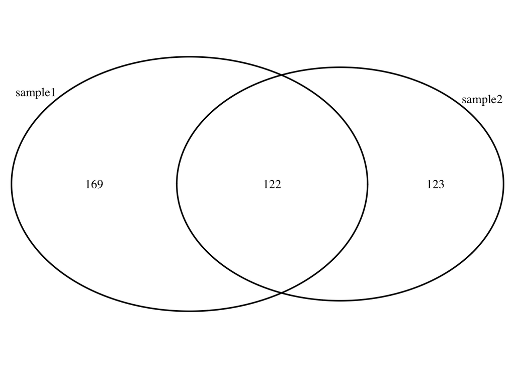

```r
z <- venn.diagram(list(sample1=x$var_id, sample2=y$var_id),
                  filename=NULL);
grid.draw(z)
```

```r
# Sanity check
length(c(unique_x,unique_y,intersect_xy)) == length(union_xy)
```

```
## [1] TRUE
```

```r
# Clean-up
rm(z)
```

# 6 Select variant annotations

## 6.1 Vector of sample-independent variant annotations

These (stable) variant annotations should not change sample to sample, e.g. Ref, ALt, Gene name etc. Such annotations will be kept within metadata of the merged GRanges object.

```r
# Review available annotations
colnames(mcols(x))
```

```
##  [1] "cytoBand"
##  [2] "Gene.refGene"
##  [3] "Func.refGene"
##  [4] "ExonicFunc.refGene"
##  [5] "avsnp150"
##  [6] "HGVS_cDNA"
##  [7] "Ref"
##  [8] "Alt"
##  [9] "CDS_Pos"
## [10] "TranscriptSize"
## [11] "HGVS_Prot"
## [12] "AA1"
## [13] "AA2"
## [14] "AA_Pos"
## [15] "ProteinSize"
```

[output cut: 84 more lines]

```r
#x.df <- as.data.frame(x)

# Select annotations to keep
stable_annotations <- c("var_id",
"Gene.refGene","Func.refGene","ExonicFunc.refGene",
"CLNSIG","CLNREVSTAT","CLNDN",
"avsnp150","HGVS_cDNA","HGVS_Prot",
"Ref","Alt",
"CDS_Pos","TranscriptSize",
"AA_Pos","AA1","AA2","ProteinSize","Interpro_domain",
"gnomAD_genome_ALL","ExAC_ALL")

length(stable_annotations)
```

```
## [1] 21
```

## 6.2 Matrices for sample-specific variant annotations

These variant annotations may change from sample to sample, such as Genotype or Drepth etc. Such annotations will be captured and stored in additional matrices, syncronised with the GRanges object.

```r
# Score
score.mx <- matrix(NA,ncol=2,nrow=length(union_xy))
rownames(score.mx) <- union_xy
colnames(score.mx) <- c(sample1_name,sample2_name)
head(score.mx)
```

```
##                               RMSzhang_SJRHB020 RMSzhang_SJRHB022
## chr2_197421031_197421031_G_A                 NA                NA
## chr7_117548770_117548770_A_-                 NA                NA
## chr10_113588287_113588287_G_A                NA                NA
## chr17_57675028_57675028_G_A                  NA                NA
## chr2_197421028_197421028_C_G                 NA                NA
## chr14_45164444_45164444_A_G                  NA                NA
```

```r
#"TruncScore"
#"HomozygScore"
#"XAcorrect"

# Other matrices

# GT
gt.mx <- matrix(NA,ncol=2,nrow=length(union_xy))
rownames(gt.mx) <- union_xy
colnames(gt.mx) <- c(sample1_name,sample2_name)
head(gt.mx)
```

```
##                               RMSzhang_SJRHB020 RMSzhang_SJRHB022
## chr2_197421031_197421031_G_A                 NA                NA
## chr7_117548770_117548770_A_-                 NA                NA
## chr10_113588287_113588287_G_A                NA                NA
## chr17_57675028_57675028_G_A                  NA                NA
## chr2_197421028_197421028_C_G                 NA                NA
## chr14_45164444_45164444_A_G                  NA                NA
```

```r
#"Depth"
#"AD"
```

# 7 Process non-overlapping variants

## 7.1 GRanges

```r
unique_x.gr <- x[unique_x,stable_annotations]
summary(unique_x.gr)
```

```
## [1] "GRanges object with 169 ranges and 21 metadata columns"
```

```r
unique_y.gr <- y[unique_y,stable_annotations]
summary(unique_y.gr)
```

```
## [1] "GRanges object with 123 ranges and 21 metadata columns"
```

## 7.2 Matrices

```r
score.mx[unique_x,sample1_name] <- as.data.frame(x[unique_x,])$Score
gt.mx[unique_x,sample1_name] <- as.data.frame(x[unique_x,])$GT

score.mx[unique_y,sample2_name] <- as.data.frame(y[unique_y,])$Score
gt.mx[unique_y,sample2_name] <- as.data.frame(y[unique_y,])$GT

rm(unique_x,unique_y)
```

# 8 Process overlapping variants

## 8.1 Granges

Check that the stable annotations are the same before making GRange

```r
# Get intersect ranges from both samples
intersect_x.gr <- x[intersect_xy,stable_annotations]
summary(intersect_x.gr)
```

```
## [1] "GRanges object with 122 ranges and 21 metadata columns"
```

```r
intersect_y.gr <- y[intersect_xy,stable_annotations]
summary(intersect_y.gr)
```

```
## [1] "GRanges object with 122 ranges and 21 metadata columns"
```

```r
# Check that intersect ranges from both samples are equal
if (!all(intersect_x.gr==intersect_y.gr)) {
  stop("GRanges shared elements differ", ok)
}

# Save the intersect
intersect_xy.gr <- intersect_x.gr

# Clean-up
rm(intersect_x.gr,intersect_y.gr,stable_annotations)
```

## 8.2 Matrices

```r
score.mx[intersect_xy,sample1_name] <- as.data.frame(x[intersect_xy,])$Score
gt.mx[intersect_xy,sample1_name] <- as.data.frame(x[intersect_xy,])$GT

score.mx[intersect_xy,sample2_name] <- as.data.frame(y[intersect_xy,])$Score
gt.mx[intersect_xy,sample2_name] <- as.data.frame(y[intersect_xy,])$GT

rm(intersect_xy,x,y)
```

# 9 Combine overlapping and non-overlapping granges

```r
# Combine granges
xy.gr <- c(unique_x.gr,unique_y.gr,intersect_xy.gr)

# Sort granges
xy.gr <- sort(xy.gr)

# Update matrices to keep order consistent with GRange
score.mx <- score.mx[xy.gr$var_id,]
gt.mx <- gt.mx[xy.gr$var_id,]

# Check result
summary(xy.gr)
```

```
## [1] "GRanges object with 414 ranges and 21 metadata columns"
```

```r
seqinfo(xy.gr)
```

```
## Seqinfo object with 25 sequences (1 circular) from hg38 genome:
##   seqnames seqlengths isCircular genome
##   chr1      248956422      FALSE   hg38
##   chr2      242193529      FALSE   hg38
##   chr3      198295559      FALSE   hg38
##   chr4      190214555      FALSE   hg38
##   chr5      181538259      FALSE   hg38
##   ...             ...        ...    ...
##   chr21      46709983      FALSE   hg38
##   chr22      50818468      FALSE   hg38
##   chrX      156040895      FALSE   hg38
##   chrY       57227415      FALSE   hg38
##   chrM          16569       TRUE   hg38
```

```r
# Compare with matrices
xy.gr[,1:2]
```

```
## GRanges object with 414 ranges and 2 metadata columns:
##                                seqnames    ranges strand |
##                                   <Rle> <IRanges>  <Rle> |
##       chr1_7738307_7738307_C_T     chr1   7738307      * |
##     chr1_17033181_17033181_C_A     chr1  17033181      * |
##     chr1_17044726_17044726_C_T     chr1  17044726      * |
##     chr1_23691787_23691787_C_G     chr1  23691787      * |
##     chr1_35832419_35832419_T_-     chr1  35832419      * |
##                            ...      ...       ...    ... .
##   chrX_119640671_119640671_C_T     chrX 119640671      * |
##   chrX_133704278_133704278_A_-     chrX 133704278      * |
##   chrX_147928745_147928745_A_C     chrX 147928745      * |
##   chrX_154368109_154368109_C_T     chrX 154368109      * |
##   chrX_154766321_154766321_G_T     chrX 154766321      * |
##                                                      var_id Gene.refGene
##                                                 <character>  <character>
##       chr1_7738307_7738307_C_T     chr1_7738307_7738307_C_T       CAMTA1
##     chr1_17033181_17033181_C_A   chr1_17033181_17033181_C_A         SDHB
##     chr1_17044726_17044726_C_T   chr1_17044726_17044726_C_T         SDHB
##     chr1_23691787_23691787_C_G   chr1_23691787_23691787_C_G        RPL11
##     chr1_35832419_35832419_T_-   chr1_35832419_35832419_T_-         AGO4
##                            ...                          ...          ...
##   chrX_119640671_119640671_C_T chrX_119640671_119640671_C_T        SEPT6
##   chrX_133704278_133704278_A_- chrX_133704278_133704278_A_-         GPC3
##   chrX_147928745_147928745_A_C chrX_147928745_147928745_A_C         FMR1
##   chrX_154368109_154368109_C_T chrX_154368109_154368109_C_T         FLNA
##   chrX_154766321_154766321_G_T chrX_154766321_154766321_G_T         DKC1
##   -------
##   seqinfo: 25 sequences (1 circular) from hg38 genome
```

```r
score.mx[1:5,]
```

```
##                            RMSzhang_SJRHB020 RMSzhang_SJRHB022
## chr1_7738307_7738307_C_T                  NA          0.540157
## chr1_17033181_17033181_C_A                 0          0.000000
## chr1_17044726_17044726_C_T                 0                NA
## chr1_23691787_23691787_C_G                 0          0.000000
## chr1_35832419_35832419_T_-                 0          0.000000
```

```r
gt.mx[1:5,]
```

```
##                            RMSzhang_SJRHB020 RMSzhang_SJRHB022
## chr1_7738307_7738307_C_T   NA                "Ref/Alt1"
## chr1_17033181_17033181_C_A "Alt1/Alt1"       "Alt1/Alt1"
## chr1_17044726_17044726_C_T "Ref/Alt1"        NA
## chr1_23691787_23691787_C_G "Alt1/Alt1"       "Alt1/Alt1"
## chr1_35832419_35832419_T_- "Ref/Alt1"        "Ref/Alt1"
```

```r
# Clean-up
rm(union_xy,unique_x.gr,unique_y.gr,intersect_xy.gr)
```

# 10 Save to SummarizedExperiment

The combination of matrices and GRanges may be stored in **SummarizedExperiment** class for consistency with existent Bioconductor solutions:

- http://bioconductor.org/packages/release/bioc/html/SummarizedExperiment.html
- http://bioconductor.org/packages/release/bioc/vignettes/SummarizedExperiment/inst/doc/SummarizedExperiment.html

```r
# Sanity checks: that objects are in sync
if (any(colnames(gt.mx) != colnames(score.mx))) {
  stop("Matrices have different samples", ok)
}

if (any(rownames(gt.mx) != rownames(score.mx))) {
  stop("Matrices have different variants", ok)
}

if (any(names(xy.gr) != rownames(gt.mx))) {
  stop("Matrices and GRanges have different variants", ok)
}

# Prepare samples info
samples <- c(sample1_name,sample2_name)
files <- c(sample1_file,sample2_file)
study <- c(sample1_study,sample2_study)
samples.df <- DataFrame(id=samples, file=files ,study=study, row.names=samples)
samples.df
```

```
## DataFrame with 2 rows and 3 columns
##                                  id
##                         <character>
## RMSzhang_SJRHB020 RMSzhang_SJRHB020
## RMSzhang_SJRHB022 RMSzhang_SJRHB022
##                                                              file       study
##                                                       <character> <character>
## RMSzhang_SJRHB020 RMSzhang_SJRHB020_hg38.bwa.QC.scores.filter.txt       Zheng
## RMSzhang_SJRHB022 RMSzhang_SJRHB022_hg38.bwa.QC.scores.filter.txt       Zheng
```

```r
# Make some metadata (optional)
metadata.ls <- list(blabla="Bla Bla Bla",source="Made by us")

# Put all data to a SummarizedExperiment container
merged.se <- SummarizedExperiment(assays=list(genotypes=gt.mx,scores=score.mx),
                     rowRanges=xy.gr, colData=samples.df, metadata=metadata.ls)

# Explore result
merged.se
```

```
## class: RangedSummarizedExperiment
## dim: 414 2
## metadata(2): blabla source
## assays(2): genotypes scores
## rownames(414): chr1_7738307_7738307_C_T chr1_17033181_17033181_C_A ...
##   chrX_154368109_154368109_C_T chrX_154766321_154766321_G_T
## rowData names(21): var_id Gene.refGene ... gnomAD_genome_ALL ExAC_ALL
## colnames(2): RMSzhang_SJRHB020 RMSzhang_SJRHB022
## colData names(3): id file study
```

```r
metadata(merged.se)
```

```
## $blabla
## [1] "Bla Bla Bla"
##
## $source
## [1] "Made by us"
```

```r
head(assays(merged.se)$scores)
```

```
##                            RMSzhang_SJRHB020 RMSzhang_SJRHB022
## chr1_7738307_7738307_C_T                  NA          0.540157
## chr1_17033181_17033181_C_A                 0          0.000000
## chr1_17044726_17044726_C_T                 0                NA
## chr1_23691787_23691787_C_G                 0          0.000000
## chr1_35832419_35832419_T_-                 0          0.000000
## chr1_35850137_35850137_-_T                NA          0.000000
```

```r
dim(assays(merged.se)$scores)
```

```
## [1] 414   2
```

```r
head(assays(merged.se)$genotypes)
```

```
##                            RMSzhang_SJRHB020 RMSzhang_SJRHB022
## chr1_7738307_7738307_C_T   NA                "Ref/Alt1"
## chr1_17033181_17033181_C_A "Alt1/Alt1"       "Alt1/Alt1"
## chr1_17044726_17044726_C_T "Ref/Alt1"        NA
## chr1_23691787_23691787_C_G "Alt1/Alt1"       "Alt1/Alt1"
## chr1_35832419_35832419_T_- "Ref/Alt1"        "Ref/Alt1"
## chr1_35850137_35850137_-_T NA                "Ref/Alt1"
```

```r
dim(assays(merged.se)$genotypes)
```

```
## [1] 414   2
```

```r
rowRanges(merged.se)[,1:2]
```

```
## GRanges object with 414 ranges and 2 metadata columns:
##                                seqnames    ranges strand |
##                                   <Rle> <IRanges>  <Rle> |
##       chr1_7738307_7738307_C_T     chr1   7738307      * |
##     chr1_17033181_17033181_C_A     chr1  17033181      * |
##     chr1_17044726_17044726_C_T     chr1  17044726      * |
##     chr1_23691787_23691787_C_G     chr1  23691787      * |
##     chr1_35832419_35832419_T_-     chr1  35832419      * |
##                            ...      ...       ...    ... .
##   chrX_119640671_119640671_C_T     chrX 119640671      * |
##   chrX_133704278_133704278_A_-     chrX 133704278      * |
##   chrX_147928745_147928745_A_C     chrX 147928745      * |
##   chrX_154368109_154368109_C_T     chrX 154368109      * |
##   chrX_154766321_154766321_G_T     chrX 154766321      * |
##                                                      var_id Gene.refGene
##                                                 <character>  <character>
##       chr1_7738307_7738307_C_T     chr1_7738307_7738307_C_T       CAMTA1
##     chr1_17033181_17033181_C_A   chr1_17033181_17033181_C_A         SDHB
##     chr1_17044726_17044726_C_T   chr1_17044726_17044726_C_T         SDHB
##     chr1_23691787_23691787_C_G   chr1_23691787_23691787_C_G        RPL11
##     chr1_35832419_35832419_T_-   chr1_35832419_35832419_T_-         AGO4
##                            ...                          ...          ...
##   chrX_119640671_119640671_C_T chrX_119640671_119640671_C_T        SEPT6
##   chrX_133704278_133704278_A_- chrX_133704278_133704278_A_-         GPC3
##   chrX_147928745_147928745_A_C chrX_147928745_147928745_A_C         FMR1
##   chrX_154368109_154368109_C_T chrX_154368109_154368109_C_T         FLNA
##   chrX_154766321_154766321_G_T chrX_154766321_154766321_G_T         DKC1
##   -------
##   seqinfo: 25 sequences (1 circular) from hg38 genome
```

```r
colData(merged.se)
```

```
## DataFrame with 2 rows and 3 columns
##                                  id
##                         <character>
## RMSzhang_SJRHB020 RMSzhang_SJRHB020
## RMSzhang_SJRHB022 RMSzhang_SJRHB022
##                                                              file       study
##                                                       <character> <character>
## RMSzhang_SJRHB020 RMSzhang_SJRHB020_hg38.bwa.QC.scores.filter.txt       Zheng
## RMSzhang_SJRHB022 RMSzhang_SJRHB022_hg38.bwa.QC.scores.filter.txt       Zheng
```

```r
# Clean-up
rm(samples,files,study,samples.df,xy.gr,gt.mx,score.mx,
   sample1_name,sample2_name,
   sample1_file,sample2_file,
   sample1_study,sample2_study,
   metadata.ls)
```

# 11 Save data

```r
save.image("s01_combine_two_samples.RData")
```

# 12 Final section

```r
ls()
```

```
## [1] "base_folder"     "data_folder"     "merged.se"       "sample1.gr"
## [5] "sample2.gr"      "scripts_fiolder"
```

```r
Sys.time()
```

```
## [1] "2021-02-23 13:01:32 GMT"
```

```r
gc()
```

```
##            used  (Mb) gc trigger  (Mb) limit (Mb) max used  (Mb)
## Ncells  5078179 271.3    8713150 465.4         NA  8713150 465.4
## Vcells 16889129 128.9   36175095 276.0      16384 30073777 229.5
```

# 13 Notes

In case of further development of this approach for GRanges merging, the following points could be kept in mind:

- Change of the **data type**
  - merge(GRanges) -> SummarisedExperiment
- Flexibility of selecting the **key** for subsetting
  - Key used in this example includes a combination of position and metadata: Position, Ref and ALt
  - Alternatively it could be different overlaps by positions: any, start, start+end, etc
- Flexibility of selecting **anotations** to keep
  - In this example we manually selected the columns to keep and their types (stable or sample-specific)
  - Alternatively, all meta-data columns could be processed fully automatically
  - It could also be done in a mixed mode: some fields are specified manually with their types, and the rest is processed automatically